# Anaemia in Peruvian children aged 6-59 months

Dataset 5: Peru DHS child anaemia and growth extract

RSR feasibility analysis

2026-08-03

# Introduction

Childhood anaemia is Peru’s most prevalent nutritional condition: roughly four in ten children aged 6-59 months fall below the 11 g/dL altitude-adjusted haemoglobin threshold, and national reduction targets have been repeatedly missed. The Peruvian Demographic and Health Survey (ENDES) measures haemoglobin in every surveyed child of this age and links it to household wealth, maternal characteristics, geography and water and sanitation conditions, which is the data structure used in published ENDES analyses of the determinants of childhood anaemia (for example Gonzales and colleagues on anaemia and altitude in Peruvian children).

**Aim.** Among Peruvian children aged 6-59 months, we examined which of child age, child sex, natural region, household wealth, maternal education, maternal indigenous identity and household water source are independently associated with anaemia, mutually adjusting for the others.

This is a *Purpose 3* analysis: several predictors are of interest and the question is which remain associated with the outcome after mutual adjustment.

# Methods

**Data source.** A cross-sectional extract of 19191 children aged 6-59 months from the Peru Demographic and Health Survey (ENDES), a nationally implemented household survey, each linked to their mother’s interview and household record.

**Variables.** The outcome is `anaemia`, a binary indicator defined as altitude-adjusted haemoglobin below 11 g/dL; the modelled event is **anaemia = Yes**. Predictors are child age in months (continuous, 6-59); child sex (reference *Female*); natural region (reference *Lima metropolitan*); household wealth quintile (reference *Poorest*); mother’s highest education (reference *Primary or none*); maternal indigenous identity (reference *No*); and an unimproved household water source (reference *No*, i.e. improved source). These seven cover child biology, geography, household socio-economic position and the environmental route to anaemia through waterborne infection and parasitism.

`haemoglobin_g_dl` is **excluded by construction**: `anaemia` is exactly `haemoglobin_g_dl < 11`, so including it would produce a deterministic, perfectly separating model. Height-for-age and stunting are also excluded because they are co-outcomes of undernutrition rather than exposures. `survey_weight` is never a predictor.

**Statistical analysis.** Logistic regression via `glm(family = binomial)`, justified because the outcome is binary; estimates are reported as odds ratios. We fitted a univariable model for each predictor first, then a single multivariable model containing all of them. Predictors were chosen in advance on subject-matter grounds, not by significance. Significance threshold 0.05; estimates are reported with 95% confidence intervals. Assumptions were checked with `performance::check_model()`. Analysis used R version 4.6.0 (2026-04-24) with tidyverse, gtsummary and performance.

**Missing data.** Complete-case analysis: 19039 of 19191 rows were analysed (152 dropped, 0.8%). The only predictor with appreciable missingness is the water-source variable.

# Results

## Sample characteristics

**Table 1. Sample characteristics by anaemia status.**

| **Characteristic** | **N** | **Overall** N = 19,039<sup>1</sup> | **No** N = 12,144<sup>1</sup> | **Yes** N = 6,895<sup>1</sup> |
| --- | --- | --- | --- | --- |
| Child age (months) | 19,039 | 33 (19, 46) | 37 (24, 49) | 23 (12, 40) |
| Child sex | 19,039 |  |  |  |
| Female |  | 9,200 (48%) | 5,932 (49%) | 3,268 (47%) |
| Male |  | 9,839 (52%) | 6,212 (51%) | 3,627 (53%) |
| Natural region | 19,039 |  |  |  |
| Lima metropolitan |  | 2,305 (12%) | 1,680 (14%) | 625 (9.1%) |
| Rest of coast |  | 5,468 (29%) | 4,060 (33%) | 1,408 (20%) |
| Highlands |  | 6,322 (33%) | 3,611 (30%) | 2,711 (39%) |
| Jungle |  | 4,944 (26%) | 2,793 (23%) | 2,151 (31%) |
| Household wealth quintile | 19,039 |  |  |  |
| Poorest |  | 5,916 (31%) | 3,111 (26%) | 2,805 (41%) |
| Poorer |  | 5,137 (27%) | 3,212 (26%) | 1,925 (28%) |
| Middle |  | 3,762 (20%) | 2,624 (22%) | 1,138 (17%) |
| Richer |  | 2,580 (14%) | 1,904 (16%) | 676 (9.8%) |
| Richest |  | 1,644 (8.6%) | 1,293 (11%) | 351 (5.1%) |
| Mother's education | 19,039 |  |  |  |
| Primary or none |  | 3,601 (19%) | 2,106 (17%) | 1,495 (22%) |
| Secondary |  | 9,434 (50%) | 5,782 (48%) | 3,652 (53%) |
| Higher |  | 6,004 (32%) | 4,256 (35%) | 1,748 (25%) |
| Mother indigenous | 19,039 | 1,993 (10%) | 976 (8.0%) | 1,017 (15%) |
| Unimproved water source | 19,039 | 1,270 (6.7%) | 638 (5.3%) | 632 (9.2%) |

<sup>1</sup> Median (Q1, Q3); n (%)

36.2% of children (6895 of 19039) were anaemic. Anaemic children are markedly younger (median 23 versus 37 months) and are over-represented in the poorest quintiles, in the highlands and jungle, and in indigenous households.

## Exploratory figure

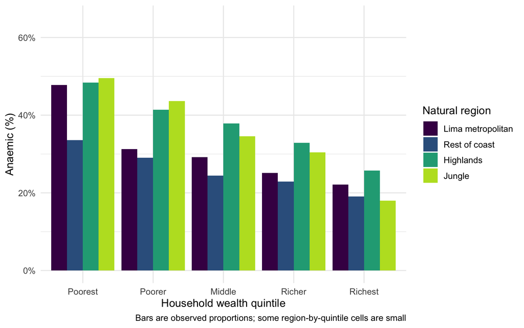

Figure 1. Prevalence of anaemia by household wealth quintile and natural region.

Anaemia prevalence falls steadily across wealth quintiles within every region, and the highlands and jungle sit above Lima and the rest of the coast at almost every level of wealth, so the two gradients are partly independent of each other.

## Univariable models

| **Characteristic** | **N** | **OR** | **95% CI** | **p-value** |
| --- | --- | --- | --- | --- |
| Child age (months) | 19,039 | 0.96 | 0.96, 0.96 | <0.001 |
| Child sex | 19,039 |  |  |  |
| Female |  | — | — |  |
| Male |  | 1.06 | 1.00, 1.12 | 0.054 |
| Natural region | 19,039 |  |  |  |
| Lima metropolitan |  | — | — |  |
| Rest of coast |  | 0.93 | 0.84, 1.04 | 0.2 |
| Highlands |  | 2.02 | 1.82, 2.24 | <0.001 |
| Jungle |  | 2.07 | 1.86, 2.31 | <0.001 |
| Household wealth quintile | 19,039 |  |  |  |
| Poorest |  | — | — |  |
| Poorer |  | 0.66 | 0.62, 0.72 | <0.001 |
| Middle |  | 0.48 | 0.44, 0.52 | <0.001 |
| Richer |  | 0.39 | 0.36, 0.44 | <0.001 |
| Richest |  | 0.30 | 0.26, 0.34 | <0.001 |
| Mother's education | 19,039 |  |  |  |
| Primary or none |  | — | — |  |
| Secondary |  | 0.89 | 0.82, 0.96 | 0.003 |
| Higher |  | 0.58 | 0.53, 0.63 | <0.001 |
| Mother indigenous | 19,039 |  |  |  |
| No |  | — | — |  |
| Yes |  | 1.98 | 1.80, 2.17 | <0.001 |
| Unimproved water source | 19,039 |  |  |  |
| No |  | — | — |  |
| Yes |  | 1.82 | 1.62, 2.04 | <0.001 |

Abbreviations: CI = Confidence Interval, OR = Odds Ratio

## Why adjustment is needed

The crude odds ratios above are not comparable to each other because the exposures overlap heavily. **Child age** confounds nearly everything: anaemia prevalence falls from about two thirds in infancy to under a quarter at four years, and the age distribution differs across regions and wealth quintiles, so any crude social contrast partly compares younger with older children. **Household wealth** confounds both the water-source and the indigenous contrasts: unimproved water supply and indigenous ethnicity are both concentrated in the poorest quintiles, and poverty independently affects diet quality, supplementation uptake and infection burden, so the crude OR of 1.82 for unimproved water is partly a poverty estimate. **Natural region** confounds the wealth gradient in turn, since the highlands and jungle are simultaneously poorer and, for the highlands, higher-altitude with a residual altitude effect that the haemoglobin adjustment formula may not fully remove. Mutual adjustment is needed before any of these can be described as independent.

## Multivariable model

| **Characteristic** | **OR** | **95% CI** | **p-value** |
| --- | --- | --- | --- |
| Child age (months) | 0.96 | 0.96, 0.96 | <0.001 |
| Child sex |  |  |  |
| Female | — | — |  |
| Male | 1.06 | 1.00, 1.13 | 0.056 |
| Natural region |  |  |  |
| Lima metropolitan | — | — |  |
| Rest of coast | 0.82 | 0.73, 0.93 | 0.001 |
| Highlands | 1.51 | 1.34, 1.70 | <0.001 |
| Jungle | 1.50 | 1.33, 1.69 | <0.001 |
| Household wealth quintile |  |  |  |
| Poorest | — | — |  |
| Poorer | 0.83 | 0.76, 0.91 | <0.001 |
| Middle | 0.68 | 0.61, 0.76 | <0.001 |
| Richer | 0.58 | 0.51, 0.66 | <0.001 |
| Richest | 0.47 | 0.40, 0.55 | <0.001 |
| Mother's education |  |  |  |
| Primary or none | — | — |  |
| Secondary | 1.10 | 1.01, 1.20 | 0.037 |
| Higher | 0.95 | 0.86, 1.06 | 0.4 |
| Mother indigenous |  |  |  |
| No | — | — |  |
| Yes | 1.25 | 1.12, 1.40 | <0.001 |
| Unimproved water source |  |  |  |
| No | — | — |  |
| Yes | 1.36 | 1.19, 1.54 | <0.001 |

Abbreviations: CI = Confidence Interval, OR = Odds Ratio

Model fit

| Statistic | Value |
| --- | --- |
| AIC | 22492.5 |
| Null deviance | 24927.6 |
| Residual deviance | 22464.5 |
| Observations | 19039.0 |
| Events (anaemia = Yes) | 6895.0 |
| Model parameters (incl. intercept) | 14.0 |
| Events per parameter | 530.4 |

## Unadjusted versus adjusted

**Table 2. Unadjusted and adjusted odds ratios.**

| **Characteristic** | **Unadjusted** **N** | **Unadjusted** **OR** | **Unadjusted** **95% CI** | **Unadjusted** **p-value** | **Adjusted** **OR** | **Adjusted** **95% CI** | **Adjusted** **p-value** |
| --- | --- | --- | --- | --- | --- | --- | --- |
| Child age (months) | 19,039 | 0.96 | 0.96, 0.96 | <0.001 | 0.96 | 0.96, 0.96 | <0.001 |
| Child sex | 19,039 |  |  |  |  |  |  |
| Female |  | — | — |  | — | — |  |
| Male |  | 1.06 | 1.00, 1.12 | 0.054 | 1.06 | 1.00, 1.13 | 0.056 |
| Natural region | 19,039 |  |  |  |  |  |  |
| Lima metropolitan |  | — | — |  | — | — |  |
| Rest of coast |  | 0.93 | 0.84, 1.04 | 0.2 | 0.82 | 0.73, 0.93 | 0.001 |
| Highlands |  | 2.02 | 1.82, 2.24 | <0.001 | 1.51 | 1.34, 1.70 | <0.001 |
| Jungle |  | 2.07 | 1.86, 2.31 | <0.001 | 1.50 | 1.33, 1.69 | <0.001 |
| Household wealth quintile | 19,039 |  |  |  |  |  |  |
| Poorest |  | — | — |  | — | — |  |
| Poorer |  | 0.66 | 0.62, 0.72 | <0.001 | 0.83 | 0.76, 0.91 | <0.001 |
| Middle |  | 0.48 | 0.44, 0.52 | <0.001 | 0.68 | 0.61, 0.76 | <0.001 |
| Richer |  | 0.39 | 0.36, 0.44 | <0.001 | 0.58 | 0.51, 0.66 | <0.001 |
| Richest |  | 0.30 | 0.26, 0.34 | <0.001 | 0.47 | 0.40, 0.55 | <0.001 |
| Mother's education | 19,039 |  |  |  |  |  |  |
| Primary or none |  | — | — |  | — | — |  |
| Secondary |  | 0.89 | 0.82, 0.96 | 0.003 | 1.10 | 1.01, 1.20 | 0.037 |
| Higher |  | 0.58 | 0.53, 0.63 | <0.001 | 0.95 | 0.86, 1.06 | 0.4 |
| Mother indigenous | 19,039 |  |  |  |  |  |  |
| No |  | — | — |  | — | — |  |
| Yes |  | 1.98 | 1.80, 2.17 | <0.001 | 1.25 | 1.12, 1.40 | <0.001 |
| Unimproved water source | 19,039 |  |  |  |  |  |  |
| No |  | — | — |  | — | — |  |
| Yes |  | 1.82 | 1.62, 2.04 | <0.001 | 1.36 | 1.19, 1.54 | <0.001 |

Abbreviations: CI = Confidence Interval, OR = Odds Ratio

## Diagnostics

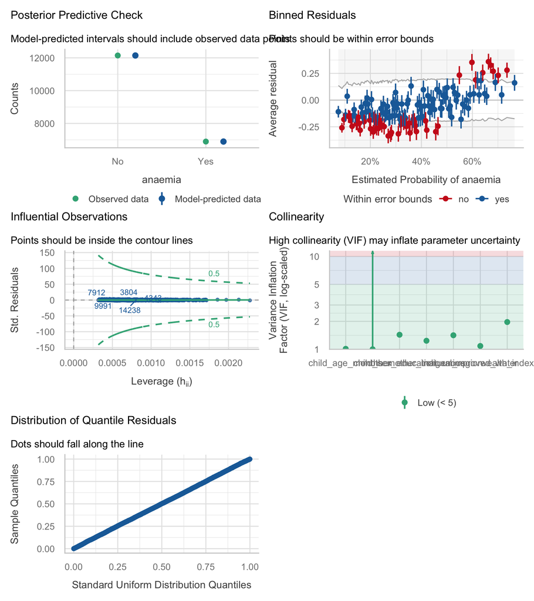

# Discussion

Anaemia in Peruvian preschool children is overwhelmingly a condition of the second year of life: adjusted odds fall by about 3.9% per month of age, so an 8-month-old has several times the odds of a 4-year-old in the same household. On top of that age effect sit a clear wealth gradient and a substantial highland and jungle excess that survives adjustment for wealth, education and ethnicity. Water source contributes an independent but smaller amount. Practically, this supports concentrating iron supplementation and screening on infants and one-year-olds, with geographic targeting of the highlands and jungle rather than socio-economic targeting alone.

**Limitations.** Cross-sectional design: haemoglobin, water source and household wealth are all measured at the same visit, so no temporal ordering is established and no causal claim is warranted. The outcome is a **dichotomised version of a continuous measurement**, which discards information and makes results sensitive to the 11 g/dL cut-point and to the altitude-adjustment formula; children in the highlands sit near the cut-point in large numbers, so misclassification is non-random with respect to a key predictor. The source ENDES analysis used the DHS complex design – cluster (HV001), stratum (HV022) and sampling weights – whereas this extract contains only the weight, which is deliberately not used here; standard errors are therefore too narrow, estimates are not design-corrected, and **this sample must not be described as nationally representative**. With 19039 rows almost everything is statistically significant, so interpretation must lead with effect sizes: the sex difference, for example, is significant in neither model and would be irrelevant even if it were. Major determinants are simply absent: iron supplementation, recent infection, dietary diversity, maternal anaemia, helminth infection and exact altitude of residence. Finally, the binned-residual check shows the linear age term does not fit well, so the age odds ratio should be read as an average slope rather than a constant effect.

**Future work.** Refit with the DHS survey design and a spline or age-group factor for child age, and if possible model haemoglobin continuously rather than dichotomised.

# Feasibility notes

*Not part of a student report.*

- **Works, with one large caveat.** 6895 events, 530.4 events per parameter, no separation, no sparse cells, maximum VIF 1.97. Statistically this is a safe logistic exercise.
- **FATAL trap: the deterministic twin.** `anaemia` is *exactly* `haemoglobin_g_dl < 11`. A student who puts haemoglobin in the model gets perfect separation and either an error or absurd odds ratios. This must be called out explicitly in the brief for this dataset; it is the single most likely way for a student to destroy this analysis.
- **Redundant with the haemoglobin outcome.** This is the same research question as `haemoglobin_g_dl`, run on a thrown-away version of the same measurement. It is a fine logistic-regression exercise, but a student should be told to do one or the other, not both, and that the continuous version is the better analysis.
- **Binned residuals fail (64.5% within bounds).** Caused by the non-linear age effect. Good teaching material, but students will need help reading the panel and will otherwise report “diagnostics fine”.
- **Education sign flip.** Secondary education reverses direction between crude and adjusted models. It is real confounding, not collinearity (VIF 1.97), but it will confuse students and needs supervision.
- **Sample size.** At 19039 rows everything is significant; the brief must force effect-size-led interpretation.
- **Design not honoured.** Only the weight is present, not cluster or stratum, so a design-correct analysis is impossible from this extract.